# Homework

徐昕怡 SA24204167

2024-12-09

# Example 1

## Question

利用控制流语句输出九九乘法表如下：

[figure not shown]

## Solution

```r
f <- function(n) { cat((1:n)*n, sep = " ", "\n") }
a <- sapply(1:9, f)
```

```
## 1
## 2 4
## 3 6 9
## 4 8 12 16
## 5 10 15 20 25
## 6 12 18 24 30 36
## 7 14 21 28 35 42 49
## 8 16 24 32 40 48 56 64
## 9 18 27 36 45 54 63 72 81
```

# Example 2

## Question

设随机变量$X, Y$服从如下分布：

$$X\sim U(0, 1)~,~Y\sim I_{X\le p}*N(\mu_1, \sigma_1)+I_{X>p}*N(\mu_2,
\sigma_2),$$

其中$U(0,1)$表示$(0,1)$上的均匀分布，$0<p<1$，$N(\mu, \sigma)$表示正态分布，$I$为示性变量。给定两组参数值：

| $p$ | $(\mu_1,\sigma_1)$ | $(\mu_2, \sigma_2)$ |
| --- | --- | --- |
| 0.5 | (0, 1) | (3, 1) |
| 0.7 | (0, 1) | (3, 1) |

独立生成两组样本，每组样本量$m=500$，绘制随机变量$Y$的样本的直方图。

## Solution

```r
set.seed(101)

m = 500; n = 1000

X <- runif(n, 0, 1)
x1 <- X[1:m]; x2 <- X[(m+1):n]

n1 <- rnorm(n, 0, 1)
n2 <- rnorm(n, 3, 1)

y1 <- (x1<=.5)*n1[1:m] + (x1>.5)*n2[1:m]
y2 <- (x2<=.7)*n1[(m+1):n] + (x2>.7)*n2[(m+1):n]

head(as.data.frame(cbind(y1, y2)))
```

```
##            y1          y2
## 1 -1.27235813  0.50319581
## 2 -0.66307158 -2.09747067
## 3  2.38577507 -0.09448458
## 4  3.56752086  1.01454241
## 5 -0.02617408  3.47402882
## 6  0.25972722  3.63742548
```

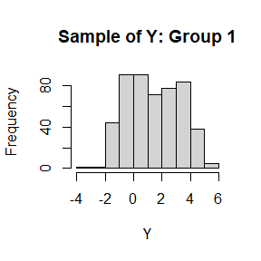

```r
hist(y1, main = "Sample of Y: Group 1", xlab = "Y")
```

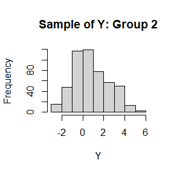

```r
hist(y2, main = "Sample of Y: Group 2", xlab = "Y")
```

# Example 3

## Question

生成200个服从多元正态的随机变量的独立样本，其中多元正态分布的各分量均值为0，给定协方差矩阵如下：
$$\Sigma =
\begin{bmatrix}
1 & -0.5 & 0.5 \\
-0.5 & 1 & -0.5 \\
0.5 & -0.5 & 1\\
\end{bmatrix}$$

按照两两分量绘制散点图，观察各分量之间的相关性。

## Solution

第一步生成样本：

```r
library(MASS)

set.seed(123)

n = 200

sigma <- diag(3)
sigma[2, 1] <- sigma[1, 2] <- sigma[3, 2] <- sigma[2, 3] <- -.5
sigma[1, 3] <- sigma[3, 1] <- .5 ## 生成协方差矩阵

x <- mvrnorm(n, mu = rep(0, 3), Sigma = sigma)

head(as.data.frame(x))
```

```
##            V1         V2         V3
## 1 -0.50009404  1.5357978  0.6630125
## 2 -0.86266035  0.5067850  0.8056280
## 3  0.90620793 -1.5884886  1.3233435
## 4  0.04091818  0.2057013  0.3374927
## 5  0.49278949 -0.1191197 -0.2952202
## 6  0.44740121 -2.1149399  1.6386930
```

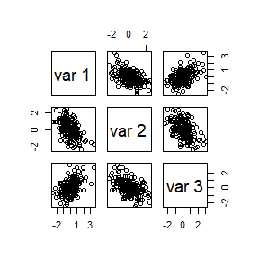

```r
pairs(x)
```

## Exercise 3.4

The Rayleigh density is

$$f(x) = \frac{x}{\sigma^2}exp(-\frac{x^2}{2\sigma^2}),~x\ge0,\sigma>0.$$

#### Question 1

Develop an algorithm to generate i.i.d. samples from a Rayleigh($\sigma$) distribution.

#### Solution

We can easily calculate the distribution function of $X\sim$ Rayleigh($\sigma$), which is given by

$$F(x)=1 - exp(-\frac{x^2}{2\sigma^2}),~x\ge0,\sigma>0.$$

Due to the fact that $U = F(X)\sim U(0, 1)$, we write

$$X = F^{-1}(U) = \sigma\sqrt{2log(\frac{1}{1-U})}.$$

We develop an algorithm with following steps:

1.Sampling from $U(0, 1)$, name them $u_1, \dots, u_n$;

2.Get samples we wanted by $x_i = F^{-1}(u_i)$.

By doing so we get the samples generated from a Rayleigh($\sigma$) distribution.

The R function `gen.Rayleigh` we develop that generates Rayleigh($\sigma$) samples of size $n$ is defined by:

```r
gen.Rayleigh <- function(n, sigma = 1){
  u = runif(n)
  x = sigma*sqrt(2*log(1/(1-u)))
  return(x)
}
```

#### Question 2

Experimenting with several choices of $\sigma>0$, histogram each group of samples and see whether their modes are close to their own $\sigma$.

#### Solution

Let $\sigma = 1, 5, 10$, generate three groups of Rayleigh samples of size $1000$:

```r
## Generate Rayleigh sample with different sigma
set.seed(124)
n = 1000
sigma.all = c(1, 5, 10)

x <- array(NA, dim = c(3, n))

for (i in 1:3){
  sigma = sigma.all[i]
  x[i, ] <- gen.Rayleigh(n, sigma)
}
```

Plotting histograms by group using package `ggplot2`:

```r
## library
library(tidyverse)
library(ggplot2)
```

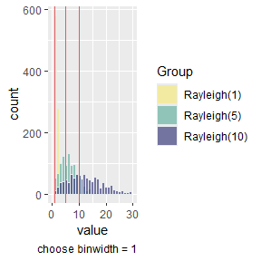

```r
## Build a dataset containing all samples, with their groups labeled
data = data.frame(Group = factor(x = c(rep(1, n), rep(2, n), rep(3, n)),
                                 levels = c(1, 2, 3),
                                 labels = c("Rayleigh(1)", "Rayleigh(5)", "Rayleigh(10)")),
                  value = c(x[1, ], x[2, ], x[3, ]))

## Represent it
p <- data %>%
  ggplot(aes(x=value, fill=Group)) +
    geom_histogram(color="#e9ecef", alpha = 0.7, position = "identity",
                   binwidth = 1) +
    scale_x_continuous(breaks = c(0, 10, 20, 30),
                       limits = c(0, 30)) +
    scale_fill_manual(values=c("#f7ea83", "#69b3a2", "#404080")) +
    geom_vline(xintercept = c(1, 5, 10), color = "#e05c5c", size = .1) +
    labs(caption = "choose binwidth = 1")
```

Note that I have marked $\sigma = (1, 5, 10)$ with vertical lines in this plot.

It is significant enough that within all the three groups, the neighborhood of the $\sigma$s are of highest frequency, while this significance mildly declines as $\sigma$ grows large.

## Exercise 3.11

#### Question 1

Generate a random sample of size $1000$ from a normal location mixture. The components of the mixture have $N(0, 1)$ and $N(3,1)$ distributions with mixing probabilities $p_1$ and $p_2 = 1- p_1$. Graph the histogram of the sample with density superimposed, for $p_1=0.75$.

#### Solution

```r
## function to generate samples

gen_mix2 <- function(p1, n = 1000, mu = c(0, 3)){
  x1 = rnorm(n, mu[1])
  x2 = rnorm(n, mu[2])

  u = sample(c(1, 0), size = n, prob = c(p1, 1-p1), replace = TRUE)

  return(u*x1 + (1-u)*x2)
}

## generate samples with p1 = 0.75
set.seed(123)
x <- gen_mix2(.75)
```

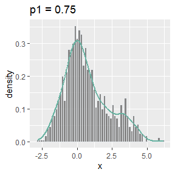

```r
## Histogram it
data = data.frame(x = x)

p <- data %>%
  ggplot(aes(x = x)) +
  geom_histogram(aes(y = ..density..),color = "#e9ecef", alpha = 0.7,
                 binwidth = 0.15) +
  geom_density(color = "#69b3a2", size = 1) +
  labs(title = "p1 = 0.75")
```

#### Question 2

Repeat with different values for $p_1$ and observe whether the empirical distribution of the mixture appears to be bimodal. Make a conjecture about the values of p1 that produce bimodal mixtures.

#### Solution

Try different values of $p_1$s. Due to the symmetry of the problem setting, here we only let $p1 = (0.5, 0.6, 0.7, 0.8, 0.9)$.

```r
## Generate samples with different p1s
n = 1000
p1 = 5:9 / 10
x = array(NA, dim = c(5, n))
for (i in 1:5){
  x[i, ] = gen_mix2(p1[i])
}
## Build dataset
dat = data.frame(value = c(x[1, ], x[2, ], x[3, ], x[4, ], x[5, ]),
                 p1 = factor(c(rep(p1[1], n), rep(p1[2], n),
                                       rep(p1[3], n), rep(p1[4], n),
                                       rep(p1[5], n))))
```

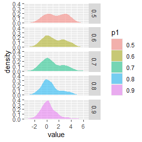

```r
## Plot them
p <- ggplot(dat) +
  geom_density(aes(x = value, fill = p1), color = NA, alpha = 0.5) +
  facet_grid(rows = vars(p1))
```

From these five plots I shall form the conjecture that $p_1$ that satisfies $0.2\le p_1\le0.8$ would well produce bimodal mixtures.

## Exercise 3.20

A *compound Poisson process* is a stochastic process $\{X(t), t\ge 0\}$ that can be represented as the random sum $X(t) = \sum_{i = 1}^{N(t)}Y_i$, $t\ge 0$, where $\{N(t), t \ge 0 \}$ is a Poisson process and $Y_1, Y_2,\dots$ are i.i.d. and independent of $\{N(t), t\ge 0\}$.

#### Question 1

Write a program to simulate a compound Poisson($\lambda$)-Gamma process.

#### Solution

A Poisson($\lambda$) process $\{N(t), t \ge 0 \}$ can be interpreted as an counting process, which yields

$$N(t + \tau) - N(t)\sim Poisson(\lambda \tau),~ t\ge 0, ~\tau\ge 0.$$

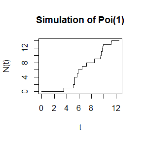

```r
## generate time nodes
tau = 0.025; m = 500
t = cumsum(c(0, rep(tau, m)))

## generate increments of Nt between time nodes
lambda = 1
h = rpois(m, lambda*tau)

## generate Nt
Nt = cumsum(c(0, h))

plot(x = t, y = Nt, type = "l",
     main = "Simulation of Poi(1)", ylab = "N(t)")
```

And then we impose $Y_i$ i.i.d. $\sim \Gamma(\alpha=2, \beta=2)$ into the model,

```r
alpha = 2; beta = 2
n = max(Nt)
y = rgamma(n, alpha, beta)
```

and we get:

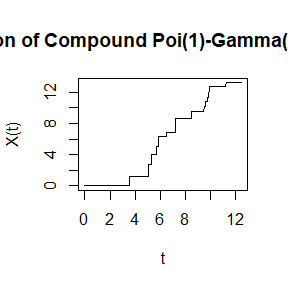

```r
y_cumsum = c(0, cumsum(y))
Xt = NULL
for (i in 0:m){
  Xt <- c(Xt, y_cumsum[Nt[i+1] + 1])
}

plot(x = t, y = Xt, type = "l",
     main = "Simulation of Compound Poi(1)-Gamma(2, 2) process",
     ylab = "X(t)")
```

#### Question 2

Estimate the mean and the variance of $X(10)$ for several choices of the parameters and compare with the theoretical values.

#### Solution

Theoretically, mean
$$E[X(t)] = \lambda t E[Y_1] = (\lambda t)\frac{\alpha}{\beta},$$
and variance

$$Var[X(t)] = \lambda t E[Y_1^2]=\lambda t (Var[Y_1]+E[Y_1]^2) = \lambda t
\frac{\alpha(1+\alpha)}{\beta^2}$$

Rewrite the solution to the former question into a function:

```r
gen_Xt <- function(lambda, alpha, beta){
  ## generate time nodes
  tau = 0.025; m = 500
  t = cumsum(c(0, rep(tau, m)))

  ## generate increments of Nt between time nodes
  h = rpois(m, lambda*tau)

  ## generate Nt
  Nt = cumsum(c(0, h))

  ## generate Gamma r.v.s
  n = max(Nt)
  y = rgamma(n, alpha, beta)

  ## generate Xt
  y_cumsum = c(0, cumsum(y))
  Xt = NULL
  for (i in 0:m){
    Xt <- c(Xt, y_cumsum[Nt[i+1] + 1])
  }
  return(data.frame(t = t, Xt = Xt))
}
```

Here lists the parameters we choose, and the functions to calculate theoretical means and variances:

```r
lambda = c(1, 2, 2)
alpha = c(1, 2, 3)
beta = c(1, 2, 1)

mean_theo <- function(l, a, b, t = 10){
  l*t*a/b
}

var_theo <- function(l, a, b, t = 10){
  l*t*a*(1 + a)/b^2
}
```

Obtain empirical means and variances through Monte-Carlo, we finally get:

```r
R = 200 ## number of reputations
mean_all <- NULL
var_all <- NULL
mean_th <- NULL
var_th <- NULL

for (j in 1:3){ ## the i-th coupling of parameters
  X10 <- NULL
  for (i in 1:R){
    X <- gen_Xt(lambda[j], alpha[j], beta[j])
    X10 <- c(X10, X[t == 10, "Xt"])
  }

  mean_all <- c(mean_all, mean(X10)) ## sample mean of X(10)
  var_all <- c(var_all, var(X10)) ## sample variance of X(10)

  ## theoretical values
  mean_th <- c(mean_th, mean_theo(lambda[j], alpha[j], beta[j]))
  var_th <- c(var_th, var_theo(lambda[j], alpha[j], beta[j]))
}

result = data.frame(lambda = lambda, alpha = alpha, beta = beta,
                    emp_mean = mean_all, theo_mean = mean_th,
                    emp_variance = var_all, theo_variance = var_th)

knitr::kable(result, align = c("l", "l", "l", "l", "l", "l", "l"))
```

| lambda | alpha | beta | emp_mean | theo_mean | emp_variance | theo_variance |
| --- | --- | --- | --- | --- | --- | --- |
| 1 | 1 | 1 | 9.958509 | 10 | 16.59114 | 20 |
| 2 | 2 | 2 | 20.279075 | 20 | 31.91771 | 30 |
| 2 | 3 | 1 | 61.131492 | 60 | 270.93760 | 240 |

## Quick Sort Algorithm

```r
## Quick sort algorithm
qs <- function(x){
  n = length(x)
  if (n == 0 || n == 1){
    return(x)
  }

  a = x[1]
  y = x[-1]
  lower = y[y < a]
  upper = y[y >= a]
  return(c(qs(lower), a, qs(upper)))
}
```

#### Requirements

For $n = 10^4, 2\times 10^4, 4\times 10^4, 6\times 10^4, 8\times 10^4$, apply the quick sort on random permutations of $(1, 2, \dots, n)$, each done with $100$ repetitions, calculate for each $n$, the average computation time, denoted by $a_n$.

Regress $a_n$ on $t_n := n\mathrm{log}(n)$, and graph the result. (Scatter plot and regression line suggested.)

#### Experiment

```r
n.all = c(1, 2, 4, 6, 8)*1e4
an = NULL
m = 100 ## repetitions

for (i in 1:5){
  n = n.all[i]
  am = rep(NA, m)
  for (j in 1:m){ ## Monte Carlo simulations
    x = sample(n) ## a permutation of 1:n
    am[j] = system.time(qs(x))[1]
  }
  an = c(an, mean(am))
}
```

And results are:

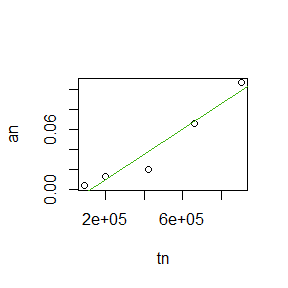

```r
tn = n.all*log(n.all)
data = data.frame(an = an, tn = tn)

plot(tn, an)

fit = lm(an~tn, data = data)
abline(fit, col = "#3db30e")
```

## Beta distribution Monte Carlo

#### Question

Write a function estimating the $\mathrm{Beta}(3, 3)$ cdf. Give Monte Carlo estimated values of $F(x), x= 0.1,\dots, 0.9$ and compare them with real ones.

#### Solution

The $k$th order statistic of $n$ i.i.d. $\mathrm{U}(0, 1)$ random variables is $\mathrm{Beta}(k, m+1-k)$. Let `m = 5`, `k = 3`, we write a function generating the order statistic, and estimate $\mathrm{Beta}(3,3)$ by empirical distribution.

First we prepare with the functions:

```r
## order statistic generator
kth.gen <- function(n, k = 3, m = 5){
  u = matrix(runif(n*m), n, m)
  for (i in 1:n){
    u[i, ] = qs(u[i, ])
  }
  return(u[, k])
}

## ecdf generator
beta.ecdf <- function(a, b){
  k = a; m = k + b - 1
  n = 1000 # sample size
  x <- kth.gen(n, k, m)
  return(ecdf(x))
}
```

Then we do the Monte Carlo estimation:

```r
R = 500 ## times of repetitions
x = 1:9/10
y = array(NA, dim = c(R, length(x)))
est = rep(0, length(x))

for (j in 1:R){
  cdf <- beta.ecdf(3, 3)
  y[j, ] = cdf(x)
}

for (k in 1:length(x)){
  est[k] = mean(y[, k])
}

data = data.frame(x = x, Fn = est, F.real = pbeta(x, 3, 3))
```

```r
knitr::kable(data, align = c("l", "l", "l"))
```

| x | Fn | F.real |
| --- | --- | --- |
| 0.1 | 0.008536 | 0.00856 |
| 0.2 | 0.058190 | 0.05792 |
| 0.3 | 0.163096 | 0.16308 |
| 0.4 | 0.317350 | 0.31744 |
| 0.5 | 0.499688 | 0.50000 |
| 0.6 | 0.683018 | 0.68256 |
| 0.7 | 0.837724 | 0.83692 |
| 0.8 | 0.942396 | 0.94208 |
| 0.9 | 0.991472 | 0.99144 |

## Antithetic variables

Generate Rayleigh($\sigma$) samples using antithetic variables, and see the percentage of variance reduction between $\frac{X+X'}{2}$ with $X,X'$ negatively correlated and $\frac{X_1+X_2}{2}$ for independent $X_1, X_2$s.

#### Solution

The pdf of Rayleigh($\sigma$) distribution is

$$f(x) = \frac{x}{\sigma^2}exp(-\frac{x^2}{2\sigma^2}),~x\ge0,\sigma>0.$$

According to the last homework, we have worked out that for $X\sim$ Rayleigh($\sigma$),

$$X = F^{-1}(U) = \sigma\sqrt{2log(\frac{1}{1-U})}.$$

and the sample generator

```r
gen.Rayleigh <- function(n, sigma = 1){
  u = runif(n)
  x = sigma*sqrt(2*log(1/(1-u)))
  return(x)
}
```

Now we do a few editions on that function, we obtain

```r
gen.Rayleigh.anti <- function(n, sigma = 1){
  stopifnot(n %% 2 == 0)
  m = n/2
  u = runif(m)
  uu = c(u, 1 - u) ## antithetic variables
  x = sigma*sqrt(2*log(1/(1-uu)))
  return(x)
}
```

We set $\sigma = 1$ as default, sample size $n=500$,

```r
x1 = gen.Rayleigh.anti(500)
x2 = gen.Rayleigh(500)

f <- function(x){
  m = length(x)
  stopifnot(m %% 2 == 0)
  y = (x[1:(m/2)] + x[(m/2 + 1):m]) / 2
  return(y)
}

y1 = f(x1)
y2 = f(x2)

var.anti = var(y1) ## antithetic method
var.indp = var(y2) ## independent sampling

(var.indp - var.anti)/var.indp ## percentage of variance reduction
```

```
## [1] 0.9443502
```

## Importance Sampling

Find two importance functions supported on $(1,\infty)$ that are close to $g(x)=\frac{x^2}{\sqrt{2\pi}}e^{-x^2/2}, x>1$, estimating the integral

$$I = \int_1^\infty g(x)dx = \int_1^\infty
\frac{x^2}{\sqrt{2\pi}}e^{-x^2/2} dx.$$

Compare and explain the variance created by different importance functions.

#### Solution

Note that the pdf of Rayleigh($\sigma$) is

$$f(x) = \frac{x}{\sigma^2}exp(-\frac{x^2}{2\sigma^2}),~x\ge0,\sigma>0,$$

then we let $\sigma = 1$, and $X = Y*I\{Y>1\}$, where $Y\sim$ Rayleigh($1$), and $I\{\cdot\}$ is the indicator function. Then $X$ is supported on $(1,\infty)$ with pdf:

$$f_1(x) = \frac{1}{1 - F(1)} f(x) = e^{1/2}~x~exp(-\frac{x^2}{2}),~x >
1,$$

where $F(x)$ is the cdf of Rayleigh($1$):

$$F(x)=1 - exp(-\frac{x^2}{2}),~x\ge0.$$

Thus we have

$$I = \int_1^\infty \frac{g(x)}{f_1(x)}f_1(x)dx =
\frac{1}{\sqrt{2\pi}e^{1/2}}\mathrm{E}_{f_1}\left[X\right].$$

```r
theta.f1 <- function(n){
  k = 0
  u <- NULL
  repeat{
    uu = runif(1)
    if (uu > 1 - exp(-1/2)){ ## F(1) = 1 - exp(-1/2)
      u <- c(u, uu)
      k <- k + 1
    }
    if (k == n) {break}
  }
  x = sqrt(2*log(1/(1-u)))
  return(x)
}
```

We consider

$$f_2(x)=\frac{1}{\sqrt{2\pi}(1-\Phi(1))}e^{-x^2/2}, x > 1,$$

where $\Phi(x)$ is the cdf of standard normal distribution. Let $X= Y*I\{Y>1\}$ where $Y\sim N(0, 1)$, then $f_2$ is the pdf of $X$.

$$I = \int_1^\infty\frac{g(x)}{f_2(x)} f_2(x)dx= (1-\Phi(1))\int_1^\infty
x^2f_2(x)dx = (1-\Phi(1))\mathrm{E}_{f_2}\left[X^2\right].$$

```r
theta.f2 <- function(n){
  k = 0
  x = NULL
  repeat{
    xx = rnorm(1)
    if (xx > 1) {x = c(x, xx); k = k + 1}
    if (k == n){break}
  }
  return(x^2)
}
```

```r
n = 500 ## sample size
c1 = exp(-1/2)/sqrt(2*pi)
c2 = 1 - pnorm(1)

## Monte Carlo estimation
theta1 <-  theta.f1(n)
intgral.hat1 <- c1 * mean(theta1)
var1 <- c1^2*var(theta1)

theta2 <- theta.f2(n)
intgral.hat2 <- c2* mean(theta2)
var2 <- c2^2*var(theta2)
```

Results are:

```r
intgral.hat1 ## f_1
```

```
## [1] 0.4099544
```

```r
intgral.hat2 ## f_2
```

```
## [1] 0.4183005
```

```r
var1 ## f_1
```

```
## [1] 0.01601788
```

```r
var2 ## f_2
```

```
## [1] 0.08618265
```

We can observe that function $f_1$ produces smaller variance than $f_2$, this is because $f_1$ is closer to $g$ than $f_2$.

## skewness test statistic $\sqrt{b_1}$

Estimate the $0.025, 0.050, 0.950, 0.975$ quantiles of sample skewness $\sqrt{b_1}$ under normality in a Monte Carlo experiment.

#### Solution

First we write a function to compute the sample skewness statistic.

```r
sk <- function(x) {## computes the sample skewness coefficient
  xbar <- mean(x)
  m3 <- mean((x - xbar)^3)
  m2 <- mean((x - xbar)^2)
  return( m3 / m2^1.5 )
}
```

Then we perform the Monte Carlo experiment.

```r
n = 500 ## sample size
m = 1000 ## times of simulations
alpha <- c(0.025, 0.05, 0.95, 0.975)
b1 = numeric(m) ## storing sample skewness

for (i in 1:m){
  x = rnorm(n)
  b1[i] = sk(x)
}

q_emp = quantile(b1, alpha) ## empirical quantiles

q_asy = qnorm(alpha, mean = 0, sd = sqrt(6/n)) ## asymptotic quantiles
```

Compare empirical quantiles with asymptotic ones:

```r
rbind(q_emp, q_asy)
```

```
##             2.5%         5%       95%     97.5%
## q_emp -0.2217401 -0.1866172 0.1868298 0.2250379
## q_asy -0.2147033 -0.1801847 0.1801847 0.2147033
```

Compute the standard error of empirical quantiles using normal approximation for the density:

```r
sd = sqrt(alpha*(1 - alpha)/(n * dnorm(q_asy)^2))
rbind(alpha, sd)
```

```
##             [,1]       [,2]       [,3]       [,4]
## alpha 0.02500000 0.05000000 0.95000000 0.97500000
## sd    0.01790965 0.02483143 0.02483143 0.01790965
```

## Powers of correlation tests

Tests for association based on Pearson product moment correlation $\rho$, Spearman’s rank correlation coefficient $\rho_s$, or Kendall’s coefficient $\tau$, are implemented in `cor.test`. Show (empirically) that the nonparametric tests based on $\rho_s$ or $\tau$ are less powerful than the correlation test when the sampled distribution is bivariate normal. Find an example of an alternative (a bivariate distribution $(X, Y )$ such that $X$ and $Y$ are dependent) such that at least one of the nonparametric tests have better empirical power than the correlation test against this alternative.

#### Solution

First we write a bivariate copula to generate samples.

```r
library(MASS)
sim.copula <- function(n, rho, qm1, qm2){
  mu <- rep(0, 2)
  M <- matrix(rho, 2, 2)
  diag(M) <- 1
  dat <- mvrnorm(n, mu, M)
  dat[,1] <- qm1(pnorm(dat[,1]))
  dat[,2] <- qm2(pnorm(dat[,2]))
  return(dat)
}
```

And then we write a function for doing Monte Carlo experiments, under marginals `qm1` and `qm2`.

```r
simu <- function(n, m, rho.all, alpha = 0.05, qm1, qm2){
  res <- array(NA, dim = c(3, length(rho.all), m))
  ## test results of Pearson, Spearman, Kendall respectively

  for (i in 1:length(rho.all)){
    rho = rho.all[i]

    for (j in 1:m){
      dat = sim.copula(n, rho, qm1, qm2)

      res[1, i, j] = (cor.test(dat[, 1], dat[, 2])$p.value < alpha)
      res[2, i, j] =
        (cor.test(dat[, 1], dat[, 2], method = "spearm")$p.value < alpha)
      res[3, i, j] =
        (cor.test(dat[, 1], dat[, 2], method = "kendall")$p.value < alpha)
    }
  }

  return(res)
}
```

Before experiment begins, we set some global variables as

```r
n = 500 ## sample size
m = 500 ## simulations
alpha = 0.05 ## significance level
rho.all = c(0.05, 0.10, 0.15)
```

When the sampled distribution is bivariate normal:

```r
res <- simu(n, m, rho.all, alpha, qnorm, qnorm)
```

```r
power1 = numeric(length(rho.all))
power2 = numeric(length(rho.all))
power3 = numeric(length(rho.all))

for (i in 1:length(rho.all)){
  power1[i] = mean(res[1, i, ]) ## pearson
  power2[i] = mean(res[2, i, ]) ## spearman
  power3[i] = mean(res[3, i, ]) ## kendall
}

rbind(rho.all, power1, power2, power3)
```

```
##          [,1]  [,2]  [,3]
## rho.all 0.050 0.100 0.150
## power1  0.218 0.642 0.922
## power2  0.196 0.582 0.880
## power3  0.194 0.580 0.878
```

As we can see, the nonparametric tests based on $\rho_s$ or $\tau$ are less powerful than the correlation test when the sampled distribution is bivariate normal.

Now we try other marginal distributions, using copula to generate dependent samples.

For example, $X\sim N(0, 1)$ and $Y\sim \mathrm{Exp}(1)$:

```r
res <- simu(n, m, rho.all, alpha, qnorm, qexp)
```

```r
power1 = numeric(length(rho.all))
power2 = numeric(length(rho.all))
power3 = numeric(length(rho.all))

for (i in 1:length(rho.all)){
  power1[i] = mean(res[1, i, ]) ## pearson
  power2[i] = mean(res[2, i, ]) ## spearman
  power3[i] = mean(res[3, i, ]) ## kendall
}

rbind(rho.all, power1, power2, power3)
```

```
##          [,1]  [,2]  [,3]
## rho.all 0.050 0.100 0.150
## power1  0.136 0.538 0.860
## power2  0.158 0.592 0.894
## power3  0.158 0.594 0.890
```

As is shown, under normal & exponential marginals, the nonparametric methods perform better than Pearson’s correlation test.

## Discussion

If we obtain the powers for two methods under a particular simulation setting with $10,000$ experiments: say, $0.651$ for one method and $0.676$ for another method. We want to know if the powers are different at $0.05$ level.

#### What is the corresponding hypothesis test problem?

$$H_0: \text{the theoretical powers of these two methods are
equal;}~~H_1:\text{they are not equal.}$$

Denote the theoretical powers by $p_1,p_2$ for these two methods respectively. Then rewrite $H_0,H_1$:

$$H_0: p_1 = p_2;~~H_1:p_1\neq p_2.$$

#### What test should we use?

(Z-test, two-sample t-test, paired-t test or McNemar test? Why?)

Suppose that the null hypothesis holds, and this power denoted by $p_1 = p_2 = p$. Denote the Monte Carlo powers of method one by $\hat p_1$ (while the other denoted by $\hat p_2$). Then $n\hat p_1\sim n\hat p_2\sim\mathrm{Binomial}(n, p)$, where $n =10000$ denotes the times of simulations.

Although this test could be done with both **two-sample t-test** and **McNemar test**, I think the former test might performs better, as $\hat p_i, i = 1,2$ are both asymptotically normal, while the latter one doesn’t rely on this.

#### Provide the least necessary information for hypothesis testing

Suppose that $H_0$ hold, then

$$z=\frac{\hat p_1-\hat p_2}{\sqrt{\hat p(1-\hat
p)\left(\frac{1}{n_1}+\frac{1}{n_2}\right)}}\rightarrow N(0, 1)$$

where $\hat p=\frac{n_1\hat p_1+n_2\hat p_2}{n_1+n_2}=\frac{\hat p_1+\hat p_2}{2}=0.6635,\hat p_1=0.651,\hat p_2 = 0.676, n_1 = n_2= 10000$.

$\alpha = 0.05$, if $|z|>z_{\alpha/2} = 1.96$, then reject $H_0$.